# Random Forest: Osteoporosis

Aigerim Kulzhabayeva

24 March 2020

## 1. Background.

This Markdown will introduce decision trees and Random forest models and Boosting method through an example: Prediction of osteoporosis fracture.

Osteoporosis is a condition that causes bones to become thin and porous, decreasing bone strength and leading to increased risk of bone fracture. The most common sites of osteoporotic fracture are the wrist, spine and hip. No single cause for osteoporosis has been identified.

## 2. Exploratory analysis.

First I would like to give variables new names that are more meningful to me.

```
## [1] 5935   54
```

### 1.1 Overview of the data

Lets first take a look at our data set graphically. We will pay attention to the classes of the variables, missing values, outliers as well as the shape of the quantile plots to get the insight about the distribution of the data.

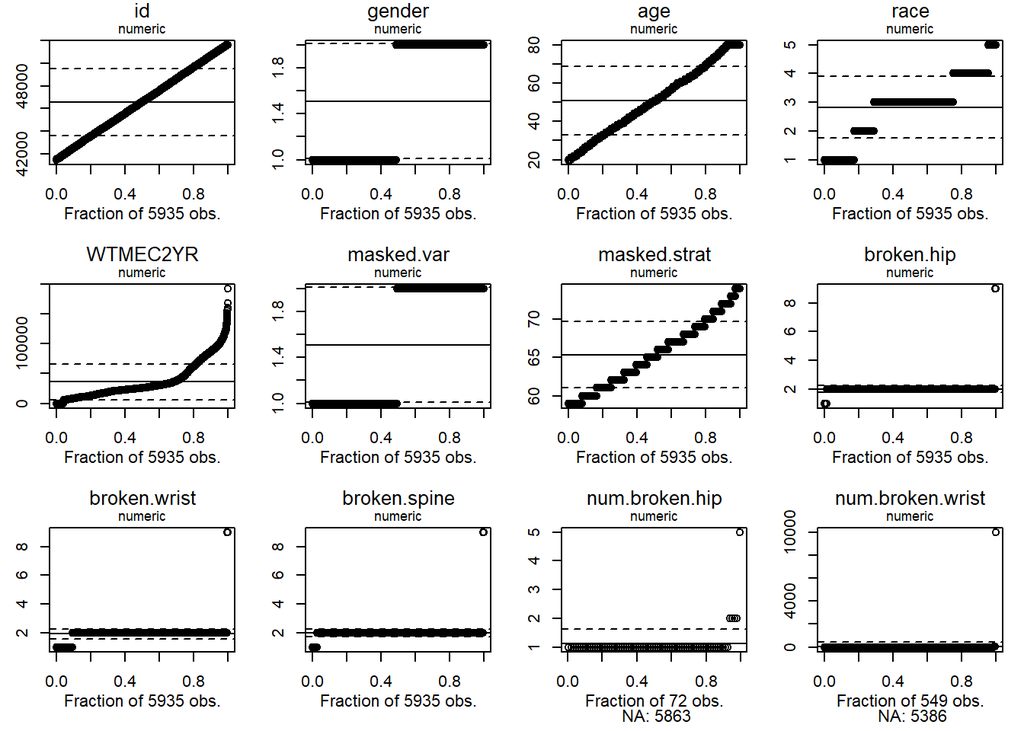

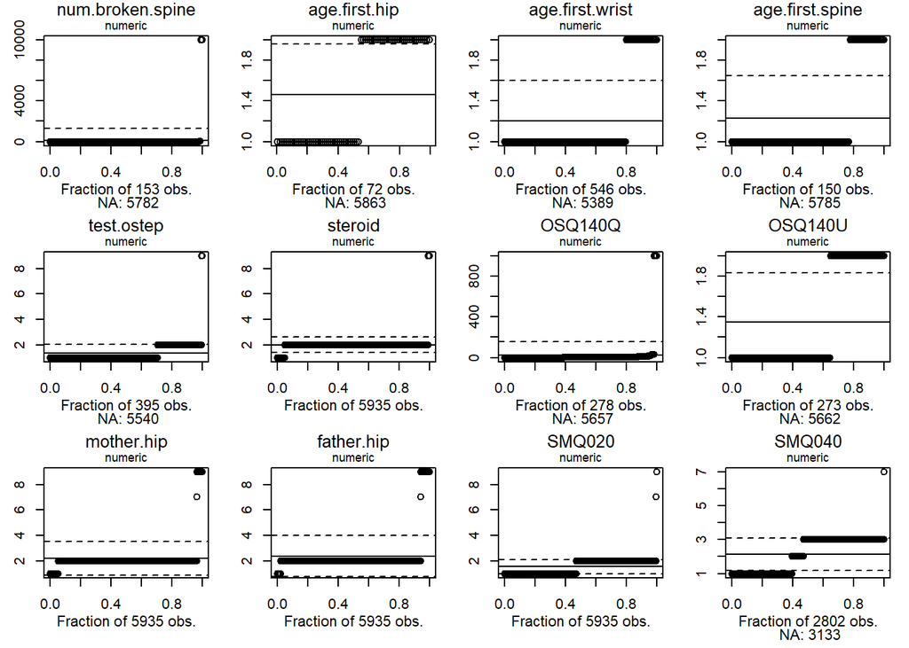

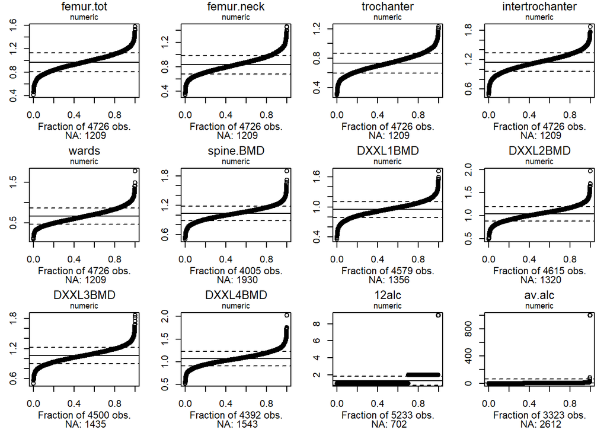

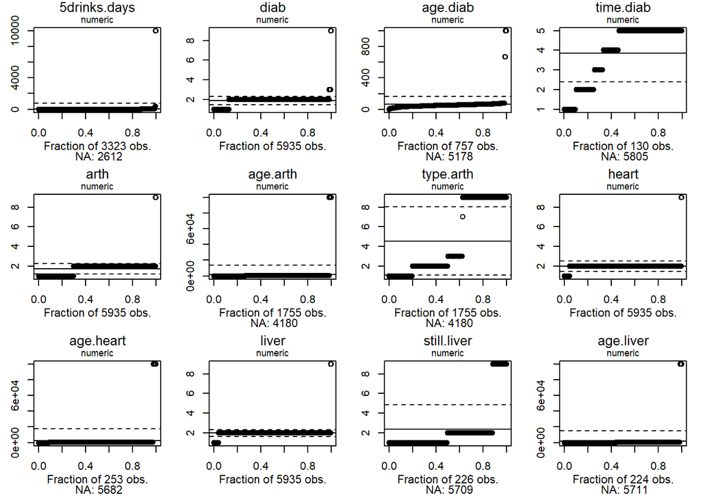

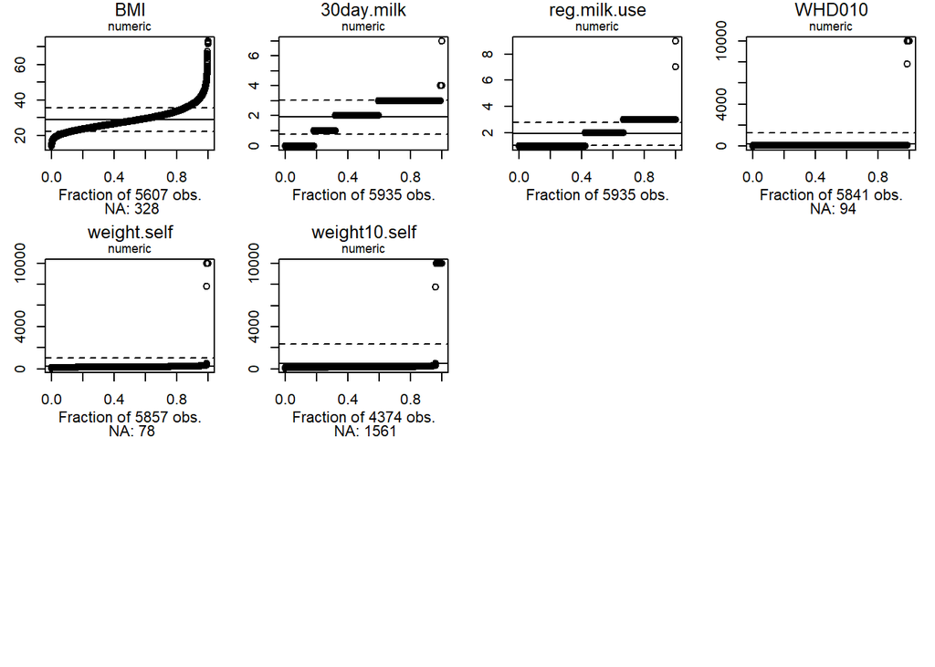

From the xq plot we see several things:

1. All variables are of class numeric, this will need to be change to the appropriate class.
2. Because numeric variables have missing values as 9999 its nearly imposible to see into the distribution of actual values.
3. There is an id variable that is unique for all samples and provides no information. We will remove that variable.

### 2.2 Assigning correct classes to the variables: numeric, factor, ordered factor.

Lets now look at xqplot with updated classes of variables.

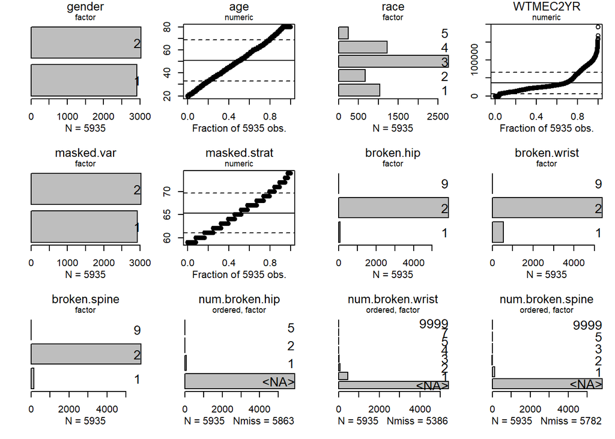

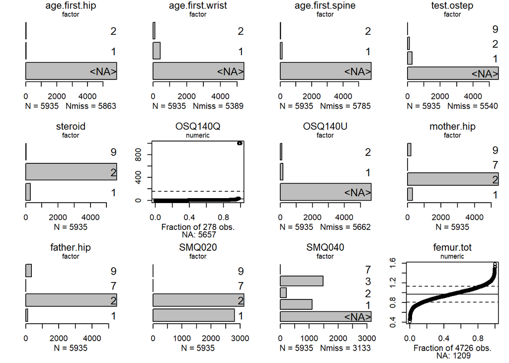

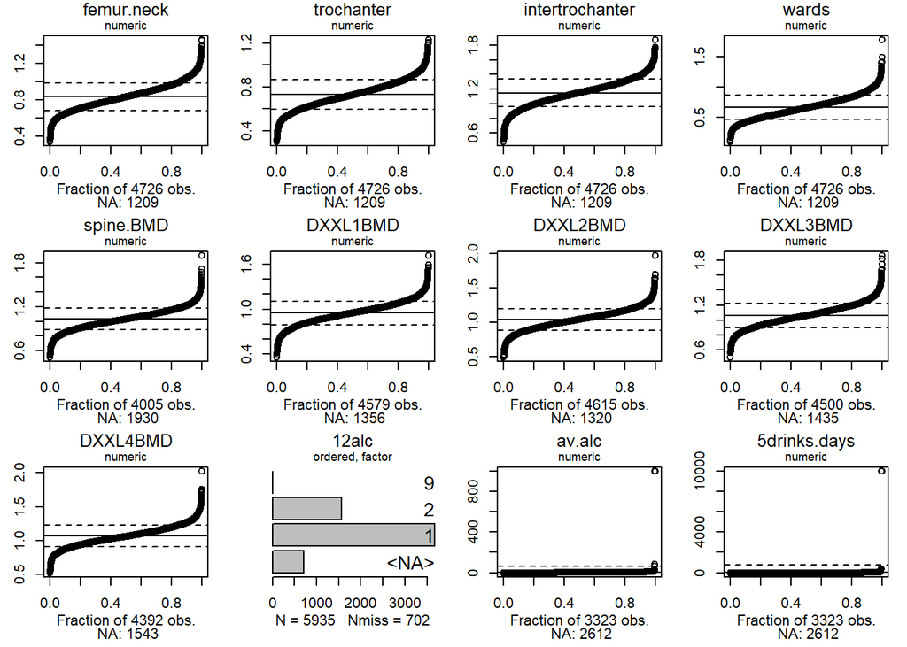

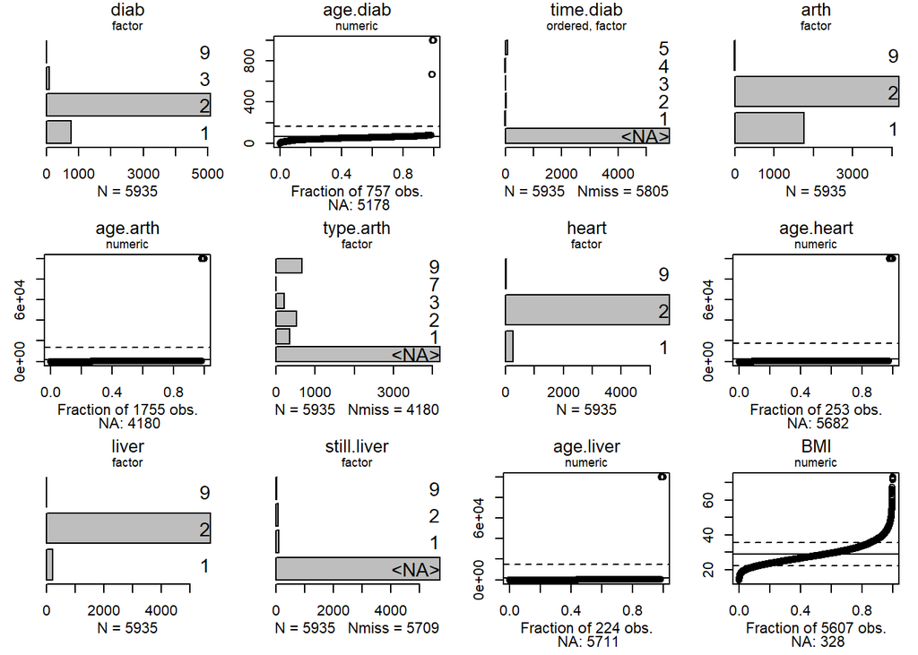

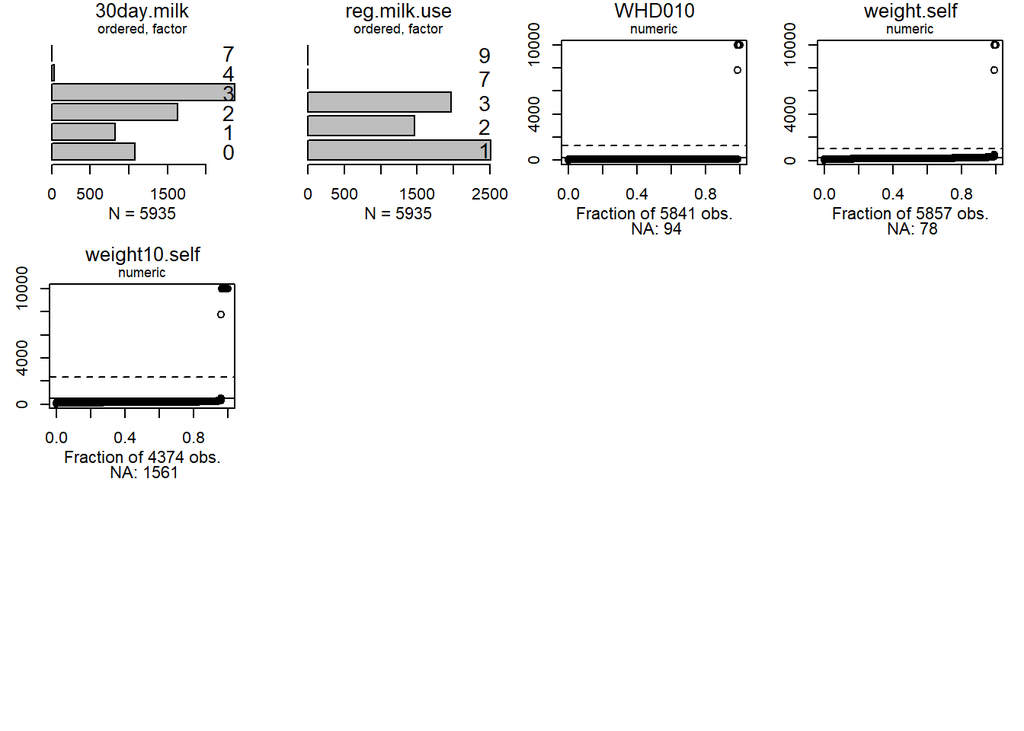

1. Variable race is unbalanced
2. WTMEC2YR? distibution is scewed
3. Varibles broken are very unbalanced
4. There are a lot of variables with a missing data, some over 90% missing.
5. For variables OSQ140Q, alc, 5drinkdays, age.diab, age.heart etc. are imposible to see the distribution because missing values are give value 9999.
6. Variable BMI is highly skewed

### 2.3 The outcome variable.

After looking at the data we realize that there seems to be no explicitly stated outcome variable. Lets at this stage formulate the questions we would like to explore and the outcome variable we will be working with.

Three variables seem to be good candidates and these are:

1. Number of times hip was broken
2. Number of times wrist was broken
3. Number of times spine was broken

#### The question we will be answering in this analysis is:

1. Can we predict a fracture
2. Which variables are associated with risk of fracture.

We will create new variable called “fracture” and will merge all types of fracture and create a binary variable woth two values: fracture occured (yes), fracture hasn’t occured (no).

Later it would be interesting to also see if we can build a better model by specifying particular location of the fracture.

[figure not shown]

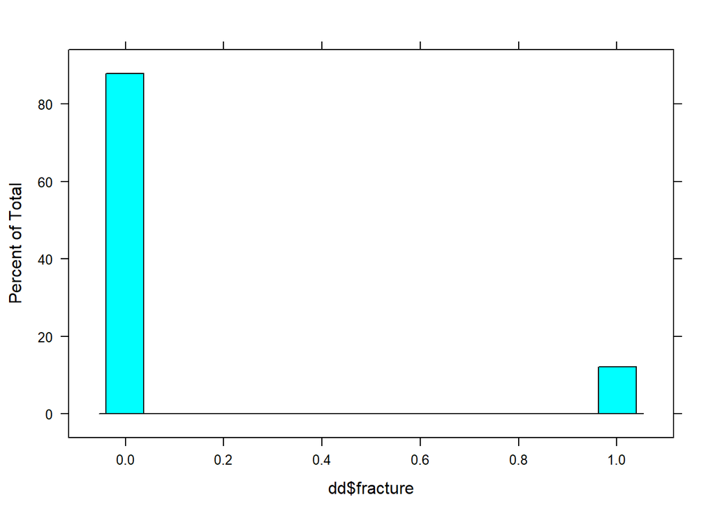

We see that the outcome variable is quite unbalanced. Now that we have identified the outcome variable and formulated the question lets move on to data cleaning. We will start with adressing the missing values.

### 2.4 Dealing with Missing Values

From the xqplot we see that there are quite a few missing values. Lets look at the variables that have missing values. We will try to understand the reason behind missingness and try to remedy it by looking at individual variables. We create a data set ddm which will include all the variables that have missing values.

```
## [1] 0.3498424
```

```
## [1] 5935   34
```

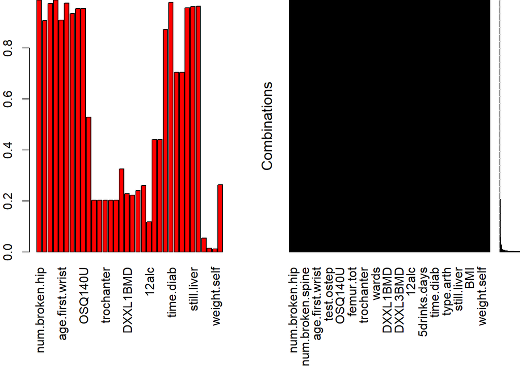

There are 34 variables that have missing values, which is more than half of the variables. Lets further narrow down by focusing on the ones that have more than 90% missing values.

```
## [1] 5935   13
```

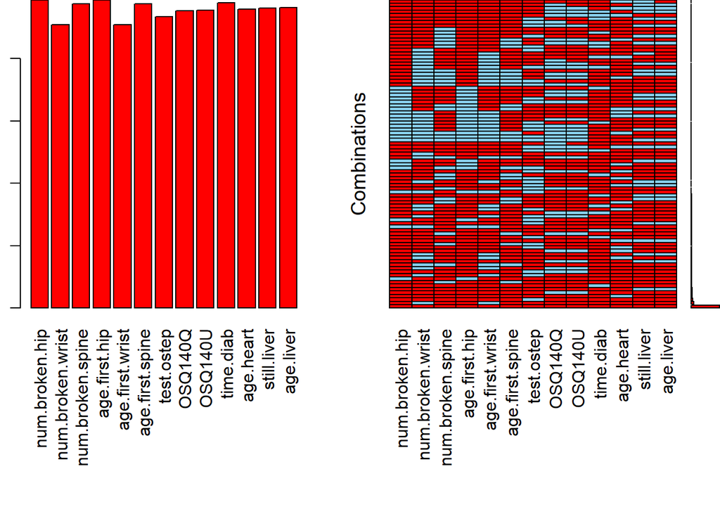

So we went down to 13 variables, which is a bit more managable.

By looking at the first three variables (num.broken.hip, num.broken.spine, num.broken.wrist) I notice that these variables have NAN when fracture in fact hasn’t happened. I will assign value of 0 to (num.broken.hip, num.broken.spine, num.broken.wrist) when (broken.hip, broken.spine,broken.wrist) is 2, meaning no fracture happened

This kind of missing mechanis is called Missing at Random (MAR), since the missingness relies on observed values of another variable.

[output not shown]

[output cut: 11857 more lines]

```
##                  num.broken.hip num.broken.spine num.broken.wrist broken.hip
## num.broken.hip            0.287            0.809           -0.297      0.072
## num.broken.spine          0.809            0.522           -0.150     -0.107
## num.broken.wrist         -0.297           -0.150            0.645     -0.096
## broken.hip                0.072           -0.107           -0.096      0.072
## broken.spine             -0.183            0.129           -0.092      0.003
## broken.wrist             -0.326           -0.206            0.315      0.004
##                  broken.spine broken.wrist
## num.broken.hip         -0.183       -0.326
## num.broken.spine        0.129       -0.206
## num.broken.wrist       -0.092        0.315
## broken.hip              0.003        0.004
## broken.spine            0.129        0.002
## broken.wrist            0.002        0.315
```

```
## [1] "1" "2" "5"
```

Lets look at the plot of missing values again.

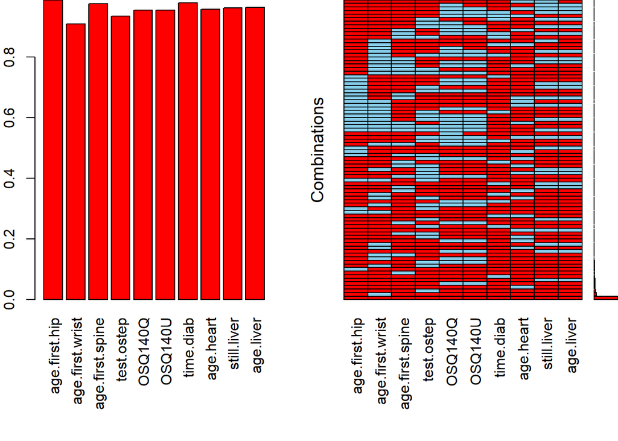

We see that those variables are no longer an issue and have no missing values.

Next lets move on to the variables that (age.first.hip, age.first.wrist, age.first.diab). These variables probably have values missing for the same reason as in previous three, however it is a bit trickier to see what value should we put for age when there has been no fracture.

These variables could help us see whether age has anything to do with probability of fracture as it tells us at what age fracture occured.

However there are other variables that are conditional on values of observed variables and they are:

1. diab, age.diab, time.diab
2. arth, age.arth, type.arth
3. heart, age.heart
4. liver, still.liver, age.liver
5. age.first.hip (broken.hip)
6. age.first.wrist (broken.wrist)
7. age.first.spine (broken.spine)

we could potentially descretize these values and create a category “not applicable” for those who do not have the disesase. For now I would like just to see whether simply having one of those condition will affect the model so I will put the variables that detail the disease aside.

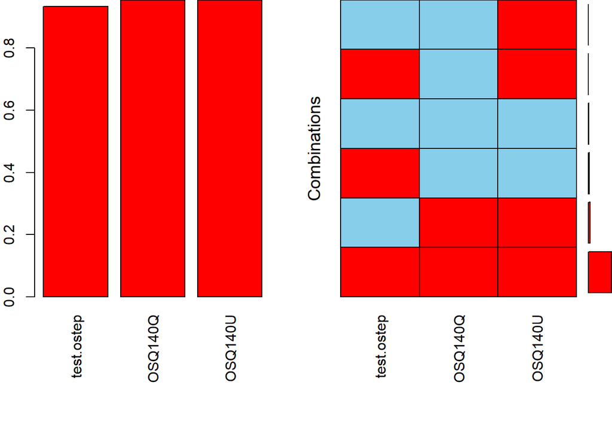

Looking at the graph we see that variable test.ostep has over 93% of dd is NaN and it doesn’t seem like we can get much information as to why form another variable.Also since the most common tests for osteoporosis includes Bone Density Mass and we have those variables available it is safe to remove this variable form the analysis.

Another troubling variable is OSQ140Q OSQ140U, thESE variables has over 95% of missing values and there is no description as to what this variable means. We will remove these variables.

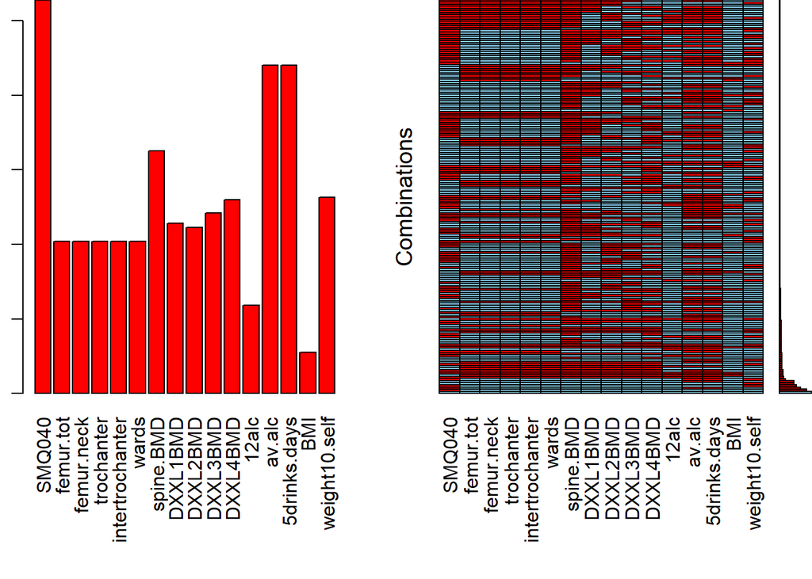

From the above plot we see that there are several patterns of missingness. There are groups of variable on the same subject that are missing.

1. Group 1: Smoking habit variable
2. Group 2: Bone mass density (BMD) variables
3. Group 3: Alcohol consumption variables
4. Group 4: Weight related variables
5. From online search I have identified that variale SMQ020 and SMQ040 pertains to smaking habits. SMQ020 - do you smoke? 1-yes, 2-no SMQ040 - how often? 1- daily, 2-sometimes, 3-not at all

when looking at the plot it seems that people who responded that they do not smoke did not indicate anything in SMQ040 variable. This means that we can put in the value of 3 in SMQ040 whenever SMQ020 is 2.

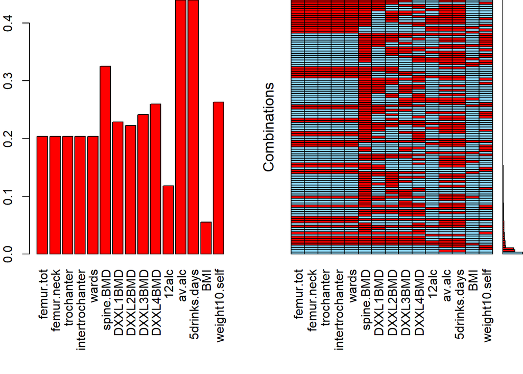

2. Now lets focus on the BMD variables. The most interesting pattern involves measurements of BMD on femur, femur.neck, trochanter, intertrochanter and ward’s triangle which are all located in pelvis. It seems that these measurements were done only when certain criteria was satisfied.

To check whether missingness depends on any variables in the data set we will create a categorical variable with missing pattern of the above variables and see if any other variable like age is used to decide necessity to measure. We will try doing this using logistic regression.

After testing several models, below is the best one. Based on results seem that the variables BMI and alcohol consumption determine whether person is tested for hip BMD variables

```
##
## Call:
## glm(formula = bmd ~ bmi + alc, family = binomial(logit), data = dd.bmd)
##
## Deviance Residuals:
##     Min       1Q   Median       3Q      Max
## -1.9038  -0.5107  -0.3971  -0.3093   2.8066
##
## Coefficients:
##               Estimate Std. Error z value Pr(>|z|)
## (Intercept)  -0.149390  88.481876  -0.002    0.999
## bmi           0.116027   0.006182  18.768   <2e-16 ***
## alc.L        11.460886 187.697979   0.061    0.951
## alc.Q         6.218453 108.367495   0.057    0.954
## ---
## Signif. codes:  0 '***' 0.001 '**' 0.01 '*' 0.05 '.' 0.1 ' ' 1
##
## (Dispersion parameter for binomial family taken to be 1)
##
##     Null deviance: 3866.4  on 5165  degrees of freedom
## Residual deviance: 3412.3  on 5162  degrees of freedom
##   (769 observations deleted due to missingness)
## AIC: 3420.3
##
## Number of Fisher Scoring iterations: 12
```

```
## Analysis of Deviance Table
##
## Model: binomial, link: logit
##
## Response: bmd
##
## Terms added sequentially (first to last)
##
##
##      Df Deviance Resid. Df Resid. Dev
## NULL                  5165     3866.4
## bmi   1   406.75      5164     3459.7
## alc   2    47.40      5162     3412.3
```

```
## [1] 46
```

```
##    bmi alc
## 1    1   1
## 2    2   2
## 3    3   1
## 4    4   2
## 5    5   1
## 6    6   2
## 7    7   1
## 8    8   2
## 9    9   1
## 10  10   2
## 11  11   1
## 12  12   2
## 13  13   1
## 14  14   2
```

[output cut: 32 more lines]

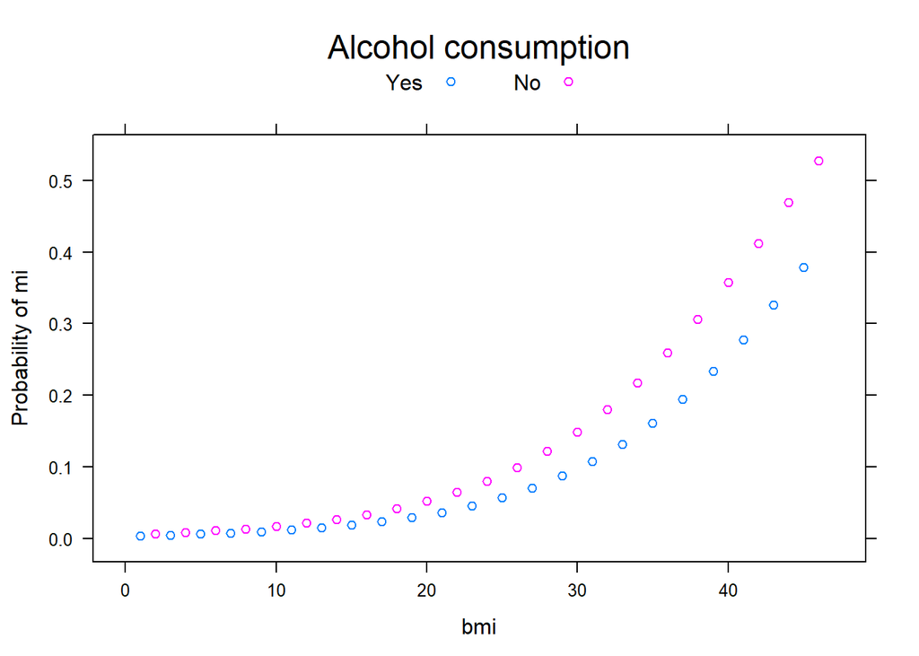

Measurement of L1 - L4 are measurements of BMD associate with L1- L4 vertibrae. spine BMD? is it total or avetage BMD? how they measure.

From above I would like to focus on alcohol consumption variable. This variable is highly unreliable because involves sensitive information. We will rely more on other variables. However we could fill in some NaN values. We have 3 variables average day consumption 0 if alc12 is 2 num days more than 5 drinks 0 if alc12 is 2